# Individual Assignment 1

BA780 - Fall 2019

**Name:**

Total points: 20

(3 points) Please add your name on the top. Submit your homework in the form of an HTML extract of an R Notebook. Include the questions in your notebook for clarity.

### Problem 1

(3 points)

1. In the `mpg` dataset from *ggplot2* package, how would you describe the relationship between `cty` and `hwy`? Plot one graph with appropriate layers to explain this relationship.
2. Most likely you have done some overplotting in the previous question (which is OK). Can you suggest a method that overcomes this overplotting and gives a better insight about the relationship in the data?

**Answer:**

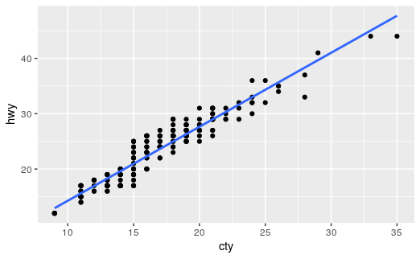

```r
library(ggplot2)
ggplot(data = mpg, mapping = aes(x = cty, y = hwy)) +
  geom_point() +
  geom_smooth(se = FALSE, method = "glm")
```

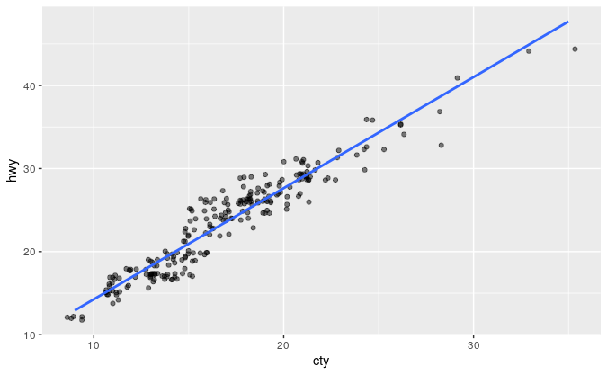

There is a clear linear relationship which is not surprising as both variables measure fuel economy.

**Rubric:**

Part 1)

- if linear relationship or equivalent concept is mentioned: 0.5 point
- if a graph that explains the relationship is plotted: 1.5 points (fitter line is optional)

Part 2)

- if jittering is used (or something equivalent) in the second chart: 1 point (alpha and fitted line are optional)

### Problem 2

(5 points)

1. Using the `mpg` dataset from *ggplot2* package, explore the 3-way relationship between fuel economy (`cty`), engine size (`displ`) and number of cylinders (`cyl`). By plotting `displ` vs. `cty` we can confirm that the bigger the engine the lower the gas mileage; how does bringing in the number of cylinders change your assessement of the relationship between engine size and fuel economy? (3 points)

Hint: Fitting a linear line will help you make a better judgement.

2. How can you explain the somewhat surprising outcome for 8 cylinder cars? Hint: use your visualization techniques to describe it. One possible explanation could be revealed by using `class` in conjunction with the other 3 aformentioned variables. (2 points)

**Answer:**

Part 1)

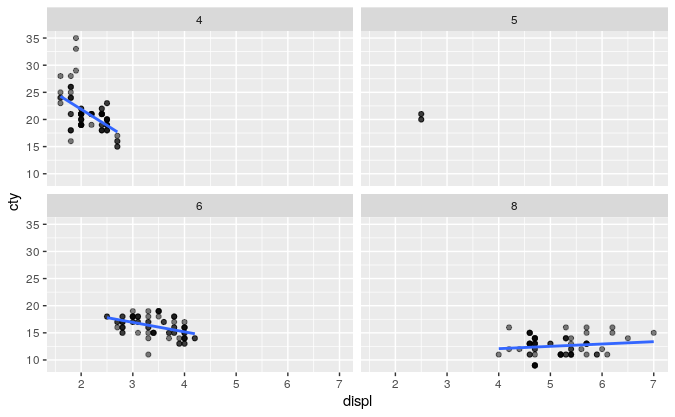

The relationship differs by cylinder number. While there is no reasonable relationship between `cyt` and `disp` for 5 cylinder cars, it is negative for 4 cylinder cars, less pronounced but still negative for 6 cylinder cars and no relationship or very small postive relationship for 8 cylinder cars.

Part 2)

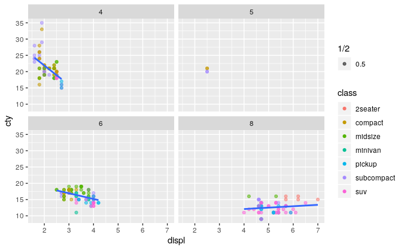

2seater cars have larger engines but smaller body weight by design. As a result they are more fuel efficient. This is causing our fit to have slightly positive slope. If we were to exclude those few datapoints we could still get a negative relationship.

**Rubric:**

Part 1)

- proper facetted graph was used (1 points) (alpha is optional)
- fitted line was used (1 point)
- correct argument was provided (1 point)

Part 2)

- `class` was used as an appropriate aesthetic. (1 point)
- correct argument was provided (1 point)

### Problem 3

(3 points)

Hint: You may try different `bindwidth` to find a good demonstration of the pattern.

**Answer:**

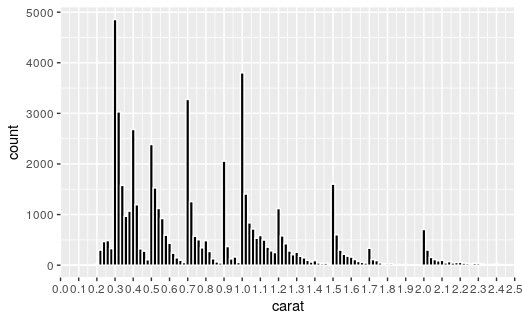

It appears that for whatever reason, rounded weights (carat) are popular in the market. Hence the spikes.

**Rubric:**

- histogram was used: 1 point
- appropriate bin width was used: 1 point
- a thoughtful argument was given: 1 point

### Problem 4

(6 points)

Create a ggplot function that contains the built-in `diamonds` dataset and an aesthetics layer. Map `carat` on the x axis and `price` on the y axis. Using + , add a `geom_point` with an `alpha` of `0.02`. Assign this initial plot to an object: `p`

Then add (+) `geom_smooth` layer to the `p` object. Map `clarity` to the color argument in the `geom_smooth` function (add `se=FALSE` to `geom_smooth` to turn off error shading). Add `theme_minimal` layer.

Note: the plot will take a few seconds to generate. Your plot should look similar to the one given below:

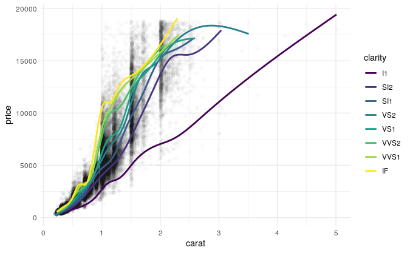

1. Reproduce this plot.
2. What is your observation?

**Answer:**

Observation: we can see that the price of these diamons increases as the weight increases. However, this increasse is more pronounced for certain clarities and changes from one to another. For instance, clarity group “IF” seems to have the highest climb by the increase of weight. In other words, on average the price of a piece of diamond from this dataset is highest for “IF” and lowest for “I1” given the same weight.

**Rubric:**

- successful reproduction of the plot (4 points)
- Appropriate logic (2 points)

**Rubric for R Markdown:**

- Notebook is readible (3 points)
- Name is missing (-1 point)
- Questions are not included in the notebook (-0.5 point)